# Robust Analytics

Primer

$\uparrow$ RAMP

**Robust Analytics** $\rightarrow$ Dev

**Google Docs** : [Why RAMP?](https://docs.google.com/document/d/18Nuk9DtUfvq4P4WqBgo2fFK11IqyDolQSl58vwoAPiw/edit#heading=h.1gjfz7n2tx94)

## -

RAMP is an acronym that means **R**obust **A**nalytics for **M**alaria **P**olicy. The goal of RAMP is to give evidence-based policy advice that is robust to uncertainty.

This is the primer for robust analytics, a guide to tutorial and instructional materials. At a high level, RAMP is a set of linked activities designed to support malaria control programs.

RAMP `dev` activities are organized around a set of activities to support adaptive malaria control. The roadmap looks something like this.

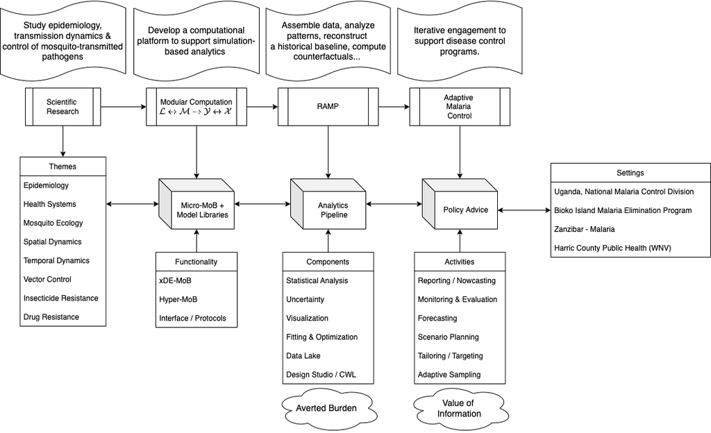

## Why RAMP?

[Why RAMP?](https://docs.google.com/document/d/18Nuk9DtUfvq4P4WqBgo2fFK11IqyDolQSl58vwoAPiw/edit#heading=h.1gjfz7n2tx94) is an introduction to RAMP. It is currently in development as a [*google doc*](https://docs.google.com/document/d/18Nuk9DtUfvq4P4WqBgo2fFK11IqyDolQSl58vwoAPiw/edit#heading=h.1gjfz7n2tx94)

**Executive Summary**

The best malaria policy is based on robust analytics – comprehensive analysis of evidence leading to policy advice that is robust to uncertainty. To do robust analytics, malaria programs must develop information systems that combine research data and routine surveillance to monitor malaria in a timely way, to evaluate program effectiveness, to formulate strategic plans, to weigh tradeoffs among policy options, and to optimize the mix of malaria control interventions under a budget constraint. While robust analytics is a challenging task for any disease, it is particularly difficult for malaria for several reasons; the transmission dynamics are complex; the baseline intensity of transmission, described by the basic reproductive number for malaria, called $R_0$, is extremely variable over time and space; in some places, $R_0>1,000$, the highest value measured for any infectious disease, making it highly refractory to control; the set of policy options is large, but the efficacy and effectiveness of these options varies by context; malaria transmission is forced by weather and land use changes, which makes it difficult to evaluate malaria control; and malaria control is undermined by the evolution of resistance. To improve malaria control by tailoring interventions to context, it is necessary to have relevant information about the local context.

Policy for malaria should thus be based on a synthesis of data describing mosquito ecology and behavior, human malaria epidemiology and behavior, complex transmission dynamics, and information about the effectiveness of interventions. To forge a synthesis, we have developed a framework for simulation-based analytics that is capable of managing and propagating uncertainty, called RAMP (Robust Analytics for Malaria Policy). RAMP is a system that is being implemented within a policy engagement process that we call adaptive malaria control.

The following document is a rationale and overview of RAMP and adaptive malaria control. It is intended to describe the overall design and supporting concepts, components, and protocols in enough technical detail for a member of a RAMP team to understand their role. Given the enormous number and complexity of tasks, RAMP analytics are organized into a pipeline that resembles a Rube-Goldberg machine. In RAMP, a lot of the work is done by a computer. Repeated tasks for RAMP analytics and adaptive malaria control must be linked in well-defined workflows: data curation; routine reporting; basic statistical analysis; development, fitting, and validation of simulation models; model calibration in context; quantification and propagation of uncertainty; forecasting; and optimization under a budget constraint; policy analysis; and communication.

What is RAMP? The document [*Why RAMP?*](https://docs.google.com/document/d/18Nuk9DtUfvq4P4WqBgo2fFK11IqyDolQSl58vwoAPiw/edit#heading=h.1gjfz7n2tx94) describes how it all fits together.

## Research

**Suggested Reading**

- McKenzie, F.E. (2000). Why model malaria? Parasitol. Today 16, 511–516.

## Simulation-Based Analytics